# Homework #1 Assignment Requirements

Warner Alexis

2024-09-17

## Introduction

In this assignment, I will be exploring, analyzing and modeing the **money ball dataset**. Each record represents a professional baseball team from the years 1871 to 2006 inclusive. Each record has the performance of the team for the given year, with all of the statistics adjusted to match the performance of a 162 game season. the purpose of this assignment is to build a multiple linear regression model on the training data to predict the number of wins for the team.

## Descriptive Analysis

> Variables:

**INDEX** Identification Variable (do not use)

**TARGET_WINS** Number of wins

**TEAM_BATTING_H** Base Hits by batters (1B,2B,3B,HR)

**TEAM_BATTING_2B** Doubles by batters (2B)

**TEAM_BATTING_3B** Triples by batters (3B)

**TEAM_BATTING_HR** Homeruns by batters (4B)

**TEAM_BATTING_BB** Walks by batters Positive

**TEAM_BATTING_HBP** Batters hit by pitch (get a free base)

**TEAM_BATTING_SO** Strikeouts by batters

**TEAM_BASERUN_SB** Stolen bases

**TEAM_BASERUN_CS** Caught stealing

**TEAM_FIELDING_E** Errors

**TEAM_FIELDING_DP** Double Plays

**TEAM_PITCHING_BB** Walks allowed

**TEAM_PITCHING_H** Hits allowed

**TEAM_PITCHING_HR** Homeruns allowed

**TEAM_PITCHING_SO** Strikeouts by pitchers

```r
# Loading library
library(tidyverse)
```

```r
library(ggplot2)
library(DataExplorer)
library(mice)
library(kableExtra)
library(corrplot)
library(reshape)
library(reshape2)
library(caret)
library(dplyr)
library(factoextra)
library(caret)  # for data splitting and pre-processing
library(stats)
```

we have two data sets: -** a training set : where most analysis will be doing -** A evaluation set Which will be used to evaluate the model

```r
# load data money ball
#evaluation set use for test set
money_ball_eval <- read.csv('moneyball-evaluation-data.csv')
# training  set
money_ball_train <- read.csv('moneyball-training-data.csv')
str(money_ball_train)
```

```
## 'data.frame':    2276 obs. of  17 variables:
##  $ INDEX           : int  1 2 3 4 5 6 7 8 11 12 ...
##  $ TARGET_WINS     : int  39 70 86 70 82 75 80 85 86 76 ...
##  $ TEAM_BATTING_H  : int  1445 1339 1377 1387 1297 1279 1244 1273 1391 1271 ...
##  $ TEAM_BATTING_2B : int  194 219 232 209 186 200 179 171 197 213 ...
##  $ TEAM_BATTING_3B : int  39 22 35 38 27 36 54 37 40 18 ...
##  $ TEAM_BATTING_HR : int  13 190 137 96 102 92 122 115 114 96 ...
##  $ TEAM_BATTING_BB : int  143 685 602 451 472 443 525 456 447 441 ...
##  $ TEAM_BATTING_SO : int  842 1075 917 922 920 973 1062 1027 922 827 ...
##  $ TEAM_BASERUN_SB : int  NA 37 46 43 49 107 80 40 69 72 ...
##  $ TEAM_BASERUN_CS : int  NA 28 27 30 39 59 54 36 27 34 ...
##  $ TEAM_BATTING_HBP: int  NA NA NA NA NA NA NA NA NA NA ...
##  $ TEAM_PITCHING_H : int  9364 1347 1377 1396 1297 1279 1244 1281 1391 1271 ...
##  $ TEAM_PITCHING_HR: int  84 191 137 97 102 92 122 116 114 96 ...
##  $ TEAM_PITCHING_BB: int  927 689 602 454 472 443 525 459 447 441 ...
##  $ TEAM_PITCHING_SO: int  5456 1082 917 928 920 973 1062 1033 922 827 ...
##  $ TEAM_FIELDING_E : int  1011 193 175 164 138 123 136 112 127 131 ...
##  $ TEAM_FIELDING_DP: int  NA 155 153 156 168 149 186 136 169 159 ...
```

```r
introduce(money_ball_train)
```

```
##   rows columns discrete_columns continuous_columns all_missing_columns
## 1 2276      17                0                 17                   0
##   total_missing_values complete_rows total_observations memory_usage
## 1                 3478           191              38692       159280
```

```r
# Data Description
money_ball_train %>%
  summary() %>%
  kable() %>% kable_styling() %>%  kable_classic(full_width = F, html_font = "Cambria")
```

|  | INDEX | TARGET_WINS | TEAM_BATTING_H | TEAM_BATTING_2B | TEAM_BATTING_3B | TEAM_BATTING_HR | TEAM_BATTING_BB | TEAM_BATTING_SO | TEAM_BASERUN_SB | TEAM_BASERUN_CS | TEAM_BATTING_HBP | TEAM_PITCHING_H | TEAM_PITCHING_HR | TEAM_PITCHING_BB | TEAM_PITCHING_SO | TEAM_FIELDING_E | TEAM_FIELDING_DP |
| --- | --- | --- | --- | --- | --- | --- | --- | --- | --- | --- | --- | --- | --- | --- | --- | --- | --- |
|  | Min. : 1.0 | Min. : 0.00 | Min. : 891 | Min. : 69.0 | Min. : 0.00 | Min. : 0.00 | Min. : 0.0 | Min. : 0.0 | Min. : 0.0 | Min. : 0.0 | Min. :29.00 | Min. : 1137 | Min. : 0.0 | Min. : 0.0 | Min. : 0.0 | Min. : 65.0 | Min. : 52.0 |
|  | 1st Qu.: 630.8 | 1st Qu.: 71.00 | 1st Qu.:1383 | 1st Qu.:208.0 | 1st Qu.: 34.00 | 1st Qu.: 42.00 | 1st Qu.:451.0 | 1st Qu.: 548.0 | 1st Qu.: 66.0 | 1st Qu.: 38.0 | 1st Qu.:50.50 | 1st Qu.: 1419 | 1st Qu.: 50.0 | 1st Qu.: 476.0 | 1st Qu.: 615.0 | 1st Qu.: 127.0 | 1st Qu.:131.0 |
|  | Median :1270.5 | Median : 82.00 | Median :1454 | Median :238.0 | Median : 47.00 | Median :102.00 | Median :512.0 | Median : 750.0 | Median :101.0 | Median : 49.0 | Median :58.00 | Median : 1518 | Median :107.0 | Median : 536.5 | Median : 813.5 | Median : 159.0 | Median :149.0 |
|  | Mean :1268.5 | Mean : 80.79 | Mean :1469 | Mean :241.2 | Mean : 55.25 | Mean : 99.61 | Mean :501.6 | Mean : 735.6 | Mean :124.8 | Mean : 52.8 | Mean :59.36 | Mean : 1779 | Mean :105.7 | Mean : 553.0 | Mean : 817.7 | Mean : 246.5 | Mean :146.4 |
|  | 3rd Qu.:1915.5 | 3rd Qu.: 92.00 | 3rd Qu.:1537 | 3rd Qu.:273.0 | 3rd Qu.: 72.00 | 3rd Qu.:147.00 | 3rd Qu.:580.0 | 3rd Qu.: 930.0 | 3rd Qu.:156.0 | 3rd Qu.: 62.0 | 3rd Qu.:67.00 | 3rd Qu.: 1682 | 3rd Qu.:150.0 | 3rd Qu.: 611.0 | 3rd Qu.: 968.0 | 3rd Qu.: 249.2 | 3rd Qu.:164.0 |
|  | Max. :2535.0 | Max. :146.00 | Max. :2554 | Max. :458.0 | Max. :223.00 | Max. :264.00 | Max. :878.0 | Max. :1399.0 | Max. :697.0 | Max. :201.0 | Max. :95.00 | Max. :30132 | Max. :343.0 | Max. :3645.0 | Max. :19278.0 | Max. :1898.0 | Max. :228.0 |
|  | NA | NA | NA | NA | NA | NA | NA | NA’s :102 | NA’s :131 | NA’s :772 | NA’s :2085 | NA | NA | NA | NA’s :102 | NA | NA’s :286 |

```r
str(money_ball_train)
```

```
## 'data.frame':    2276 obs. of  17 variables:
##  $ INDEX           : int  1 2 3 4 5 6 7 8 11 12 ...
##  $ TARGET_WINS     : int  39 70 86 70 82 75 80 85 86 76 ...
##  $ TEAM_BATTING_H  : int  1445 1339 1377 1387 1297 1279 1244 1273 1391 1271 ...
##  $ TEAM_BATTING_2B : int  194 219 232 209 186 200 179 171 197 213 ...
##  $ TEAM_BATTING_3B : int  39 22 35 38 27 36 54 37 40 18 ...
##  $ TEAM_BATTING_HR : int  13 190 137 96 102 92 122 115 114 96 ...
##  $ TEAM_BATTING_BB : int  143 685 602 451 472 443 525 456 447 441 ...
##  $ TEAM_BATTING_SO : int  842 1075 917 922 920 973 1062 1027 922 827 ...
##  $ TEAM_BASERUN_SB : int  NA 37 46 43 49 107 80 40 69 72 ...
##  $ TEAM_BASERUN_CS : int  NA 28 27 30 39 59 54 36 27 34 ...
##  $ TEAM_BATTING_HBP: int  NA NA NA NA NA NA NA NA NA NA ...
##  $ TEAM_PITCHING_H : int  9364 1347 1377 1396 1297 1279 1244 1281 1391 1271 ...
##  $ TEAM_PITCHING_HR: int  84 191 137 97 102 92 122 116 114 96 ...
##  $ TEAM_PITCHING_BB: int  927 689 602 454 472 443 525 459 447 441 ...
##  $ TEAM_PITCHING_SO: int  5456 1082 917 928 920 973 1062 1033 922 827 ...
##  $ TEAM_FIELDING_E : int  1011 193 175 164 138 123 136 112 127 131 ...
##  $ TEAM_FIELDING_DP: int  NA 155 153 156 168 149 186 136 169 159 ...
```

## Data Preparation

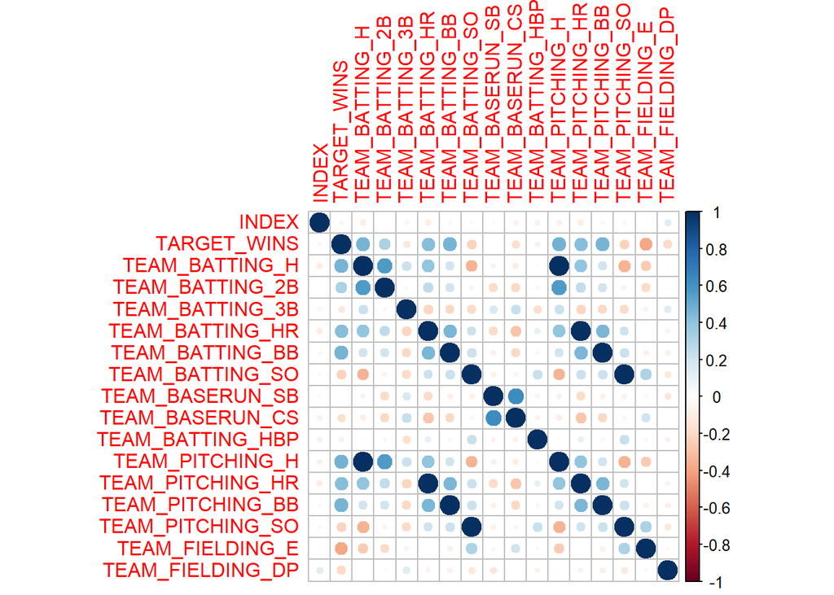

```r
# Correlation Plot
cor_matrix <- cor(money_ball_train, use = 'complete.obs')
corrplot(cor_matrix, method = 'circle')
```

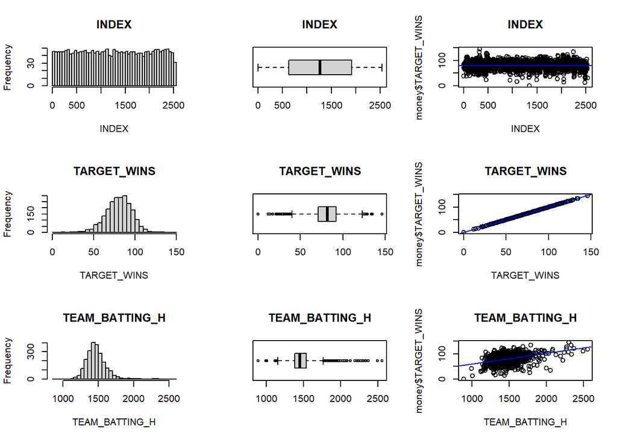

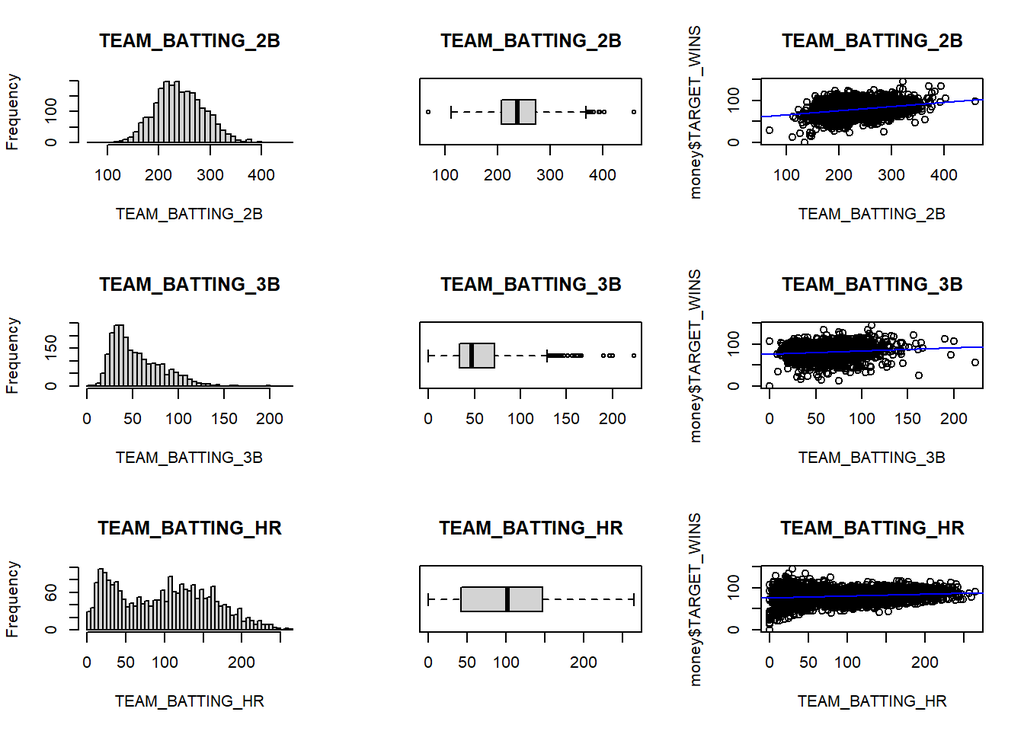

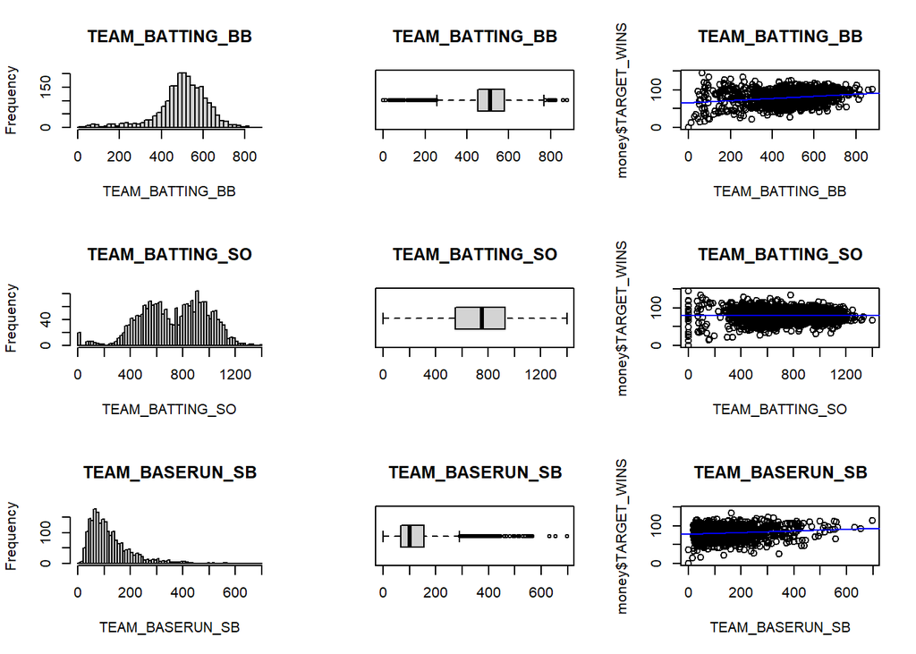

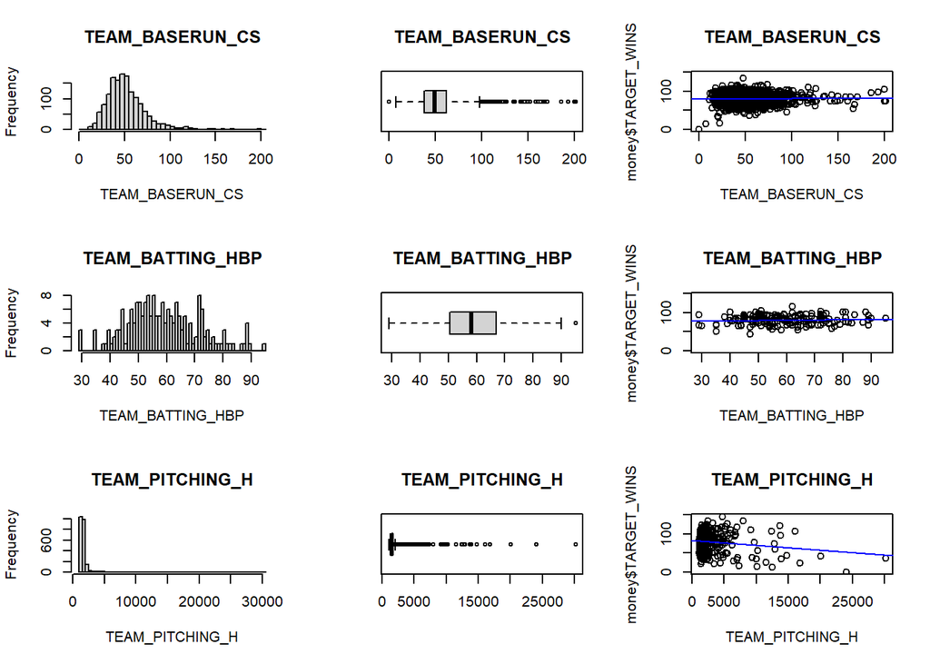

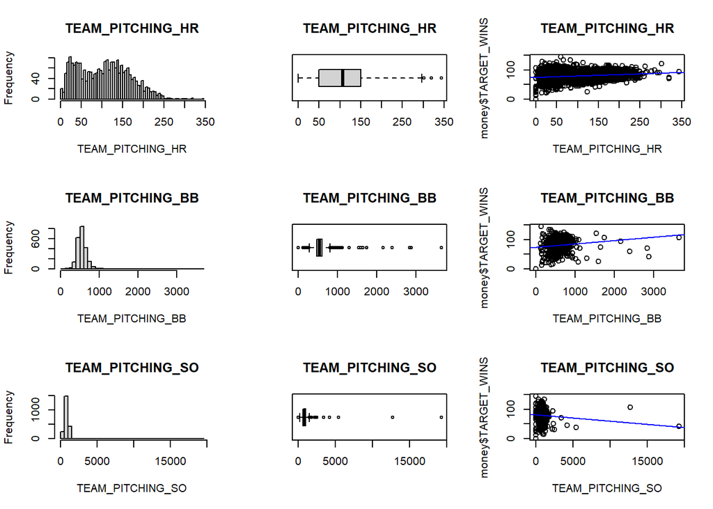

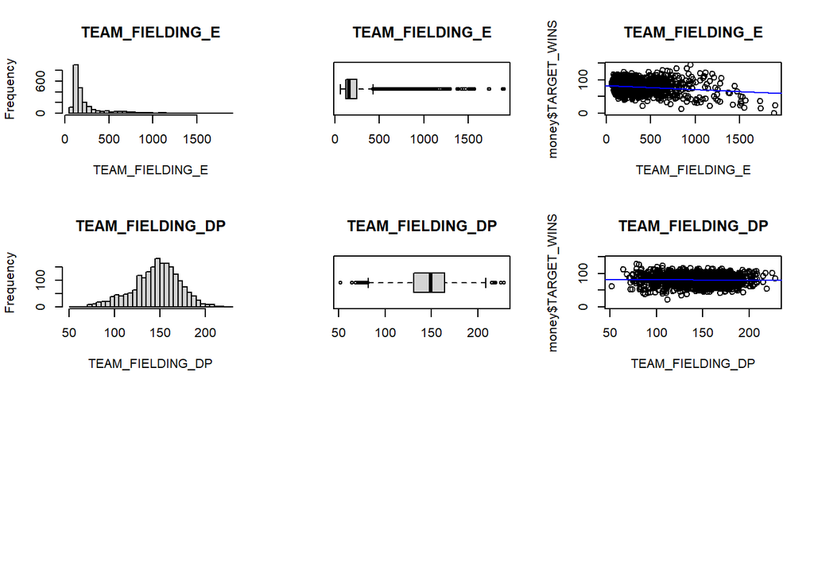

```r
money <- money_ball_train
# Create missing data flags

# Create missing data flags
#missing_flag <- ifelse(is.na(money_ball_train$TEAM_BATTING_HBP), 1, 2)
#money_ball_train$missing_flag <- missing_flag


par(mfrow=c(3,3))
# Create distribution plot to check outliers
for (i in 1:17) {
  hist(money[,i],main=names(money[i]),xlab=names(money[i]),breaks = 51)
  boxplot(money[,i], main=names(money[i]), type="l",horizontal = TRUE)

  plot(money[,i], money$TARGET_WINS, main = names(money[i]), xlab=names(money[i]))
  abline(lm(money$TARGET_WINS ~ money[,i], data = money), col = "blue")
}
```

The relationship between the target variable and the predictors is not particularly strong, but there are statistically significant relationships with certain variables. The calculate_correlations_with_pvalues function computes the correlation coefficients and p-values between a given target variable and all other predictor variables in a dataset. It first validates the input to ensure that the target variable is present and that the data contains no missing values. For each predictor, the function performs a correlation test using cor.test(), which returns both the correlation coefficient and the corresponding p-value. These results are stored in a data frame, with both the correlation and p-value rounded to 10 decimal places for precision. This function offers a clear, organized output, making it easy for users to evaluate the strength and statistical significance of the relationships between the target variable and the predictors.

```r
calculate_correlations_with_pvalues <- function(data, target_col) {
  # Check if target_col is a character string
  if (!is.character(target_col) || length(target_col) != 1) {
    stop("target_col must be a single character string.")
  }

  # Ensure the target column exists in the data
  if (!target_col %in% names(data)) {
    stop("Target column not found in the dataframe.")
  }

  # Remove rows with missing values
  data_complete <- data[complete.cases(data), ]

  # Initialize a results data frame
  results <- data.frame(Predictor = character(), Correlation = numeric(), PValue = numeric(), stringsAsFactors = FALSE)

  # Loop through each predictor variable
  for (predictor in names(data_complete)[names(data_complete) != target_col]) {
    # Perform the correlation test
    test_result <- cor.test(data_complete[[predictor]], data_complete[[target_col]])

    # Store the rounded results to 10 decimal places
    results <- rbind(results, data.frame(Predictor = predictor,
                                         Correlation = round(test_result$estimate, 10),
                                         PValue = round(test_result$p.value, 10)))
  }

  return(results)
}


# Example usage
correlation_results <- calculate_correlations_with_pvalues(money_ball_train, "TARGET_WINS")

# View the results
print(correlation_results)
```

```
##              Predictor Correlation       PValue
## cor              INDEX -0.04895047 0.5012836479
## cor1    TEAM_BATTING_H  0.46994665 0.0000000000
## cor2   TEAM_BATTING_2B  0.31298400 0.0000104138
## cor3   TEAM_BATTING_3B -0.12434586 0.0865523694
## cor4   TEAM_BATTING_HR  0.42241683 0.0000000012
## cor5   TEAM_BATTING_BB  0.46868793 0.0000000000
## cor6   TEAM_BATTING_SO -0.22889273 0.0014476066
## cor7   TEAM_BASERUN_SB  0.01483639 0.8385814774
## cor8   TEAM_BASERUN_CS -0.17875598 0.0133534492
## cor9  TEAM_BATTING_HBP  0.07350424 0.3122327101
## cor10  TEAM_PITCHING_H  0.47123431 0.0000000000
## cor11 TEAM_PITCHING_HR  0.42246683 0.0000000011
## cor12 TEAM_PITCHING_BB  0.46839882 0.0000000000
## cor13 TEAM_PITCHING_SO -0.22936481 0.0014142043
## cor14  TEAM_FIELDING_E -0.38668800 0.0000000329
## cor15 TEAM_FIELDING_DP -0.19586601 0.0066174528
```

Now let dive into the Missing values.

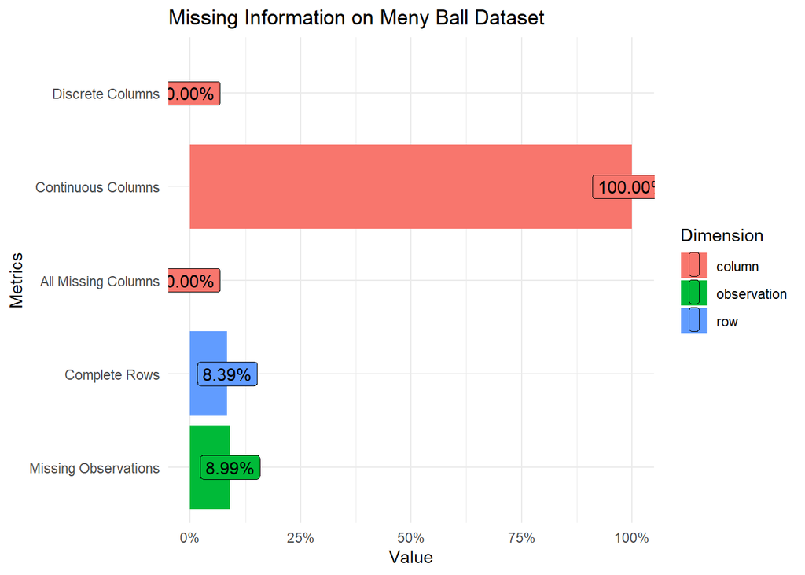

```r
#
plot_intro(money_ball_train, title = 'Missing Information on Meny Ball Dataset',
           ggtheme = theme_minimal())
```

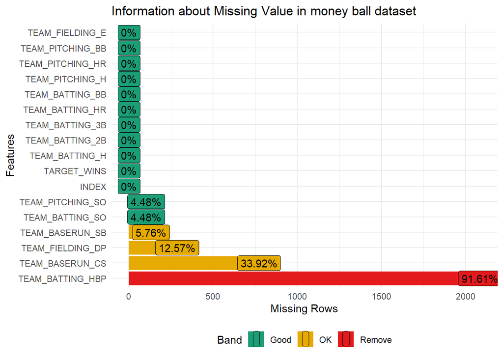

```r
# Plot missing volume in Column
plot_missing(money_ball_train,title = 'Information about Missing Value in money ball dataset',ggtheme = theme_minimal())
```

**Why Use Predictive Imputation?**

**Preserves Relationships**: Predictive imputation uses the relationships between variables to estimate missing values, which can lead to more accurate and reliable data sets.

**Handles Different Types of Missing Data**: It can handle data that is Missing Completely at Random (MCAR), Missing at Random (MAR), and even some cases of Missing Not at Random (MNAR). **Maintains Variability**: Unlike simple imputation methods (mean, median), predictive imputation maintains the natural variability in the data.

```r
# re-assign moneyball
money <- money_ball_train
# create data set with with predictive imputable
# Compute multiple imputation
data1 <- mice(money, method = 'pmm', m=5)
completed_data <- complete(data1)

money_ball_eval <- mice(money_ball_eval, method = 'pmm', m=5)
```

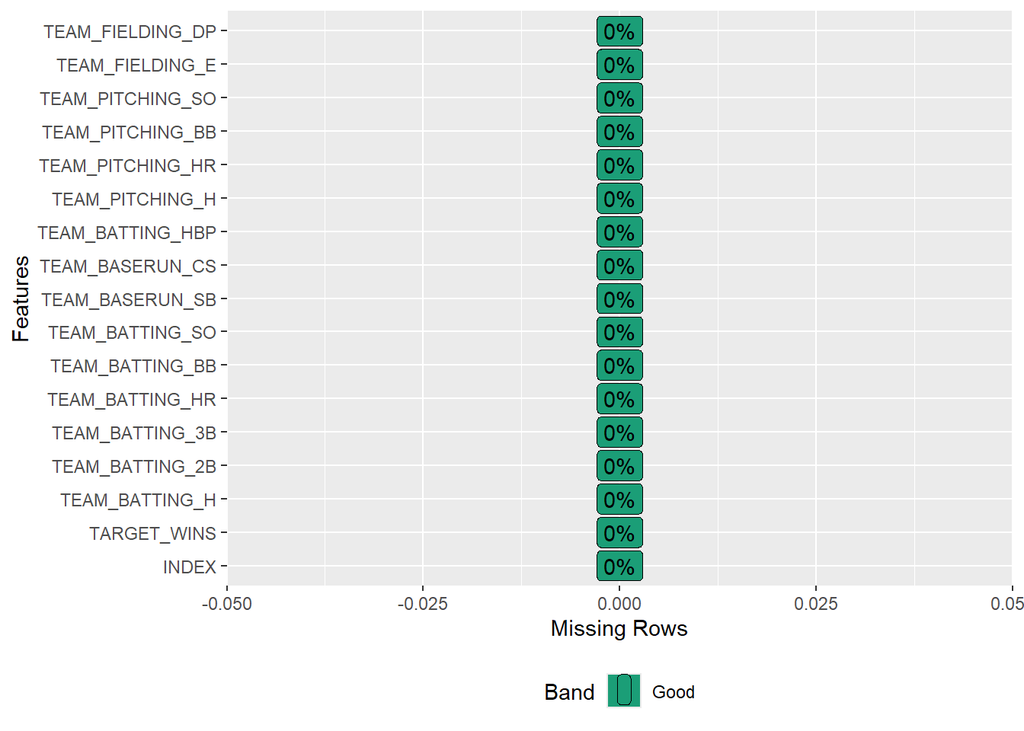

```r
money_ball_eval <- complete(money_ball_eval)
# View missing value distribution
plot_missing(completed_data)
```

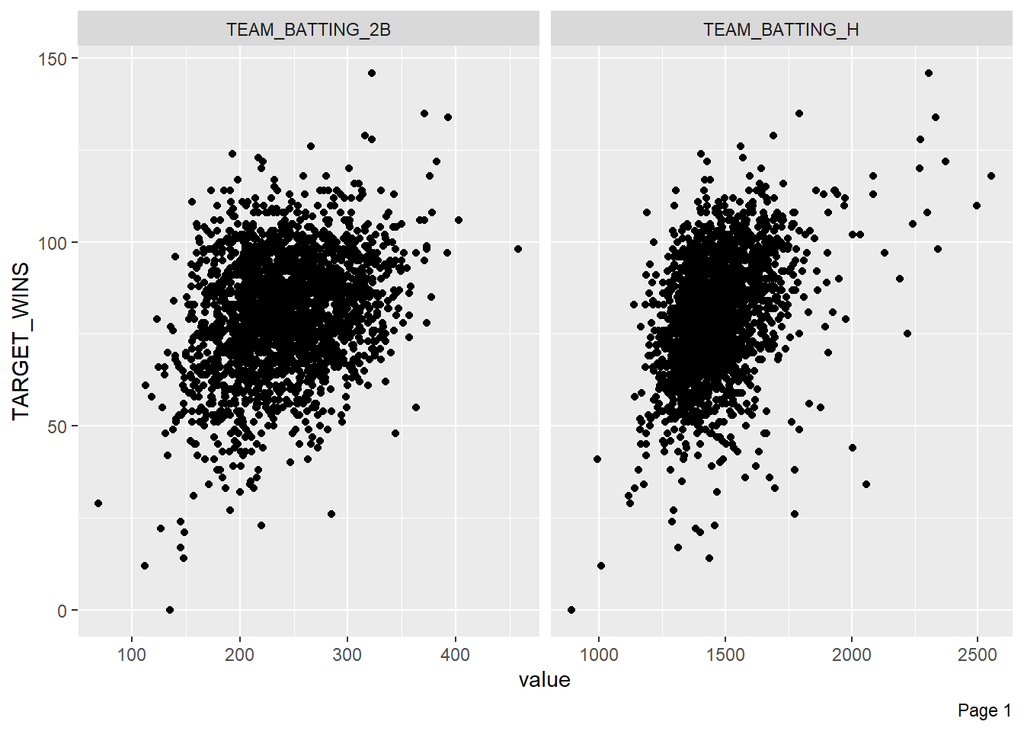

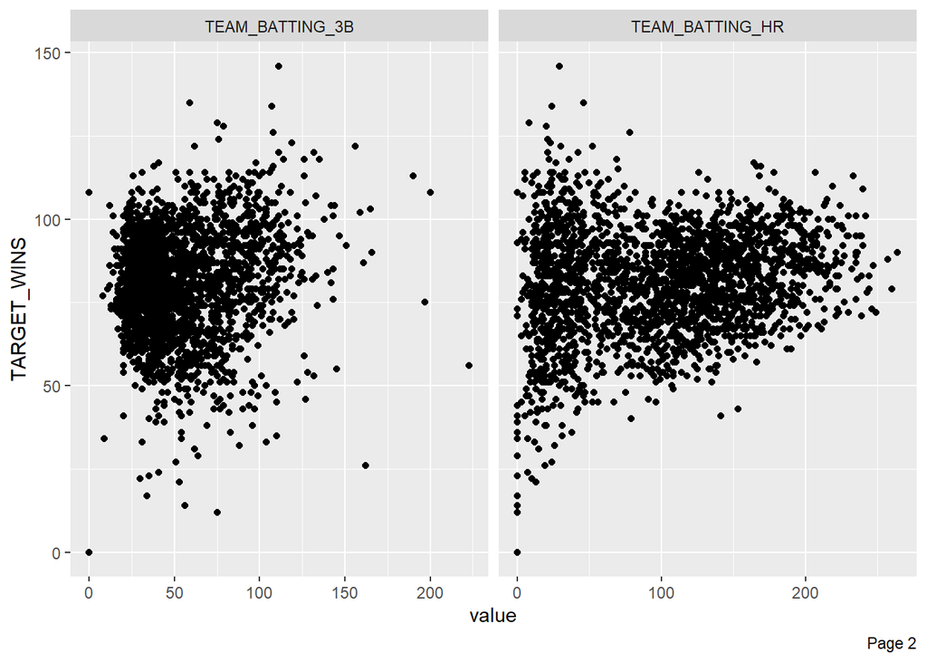

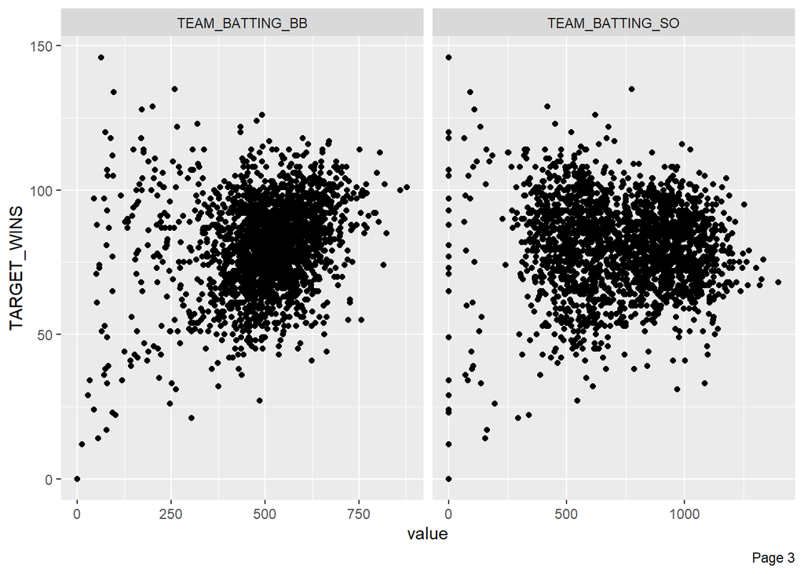

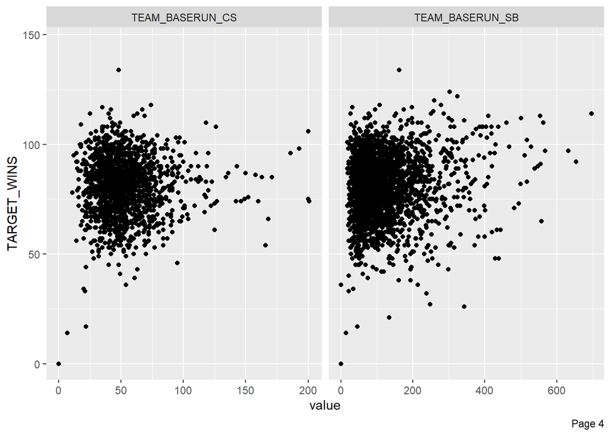

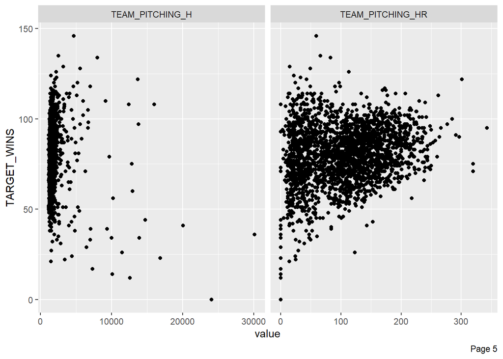

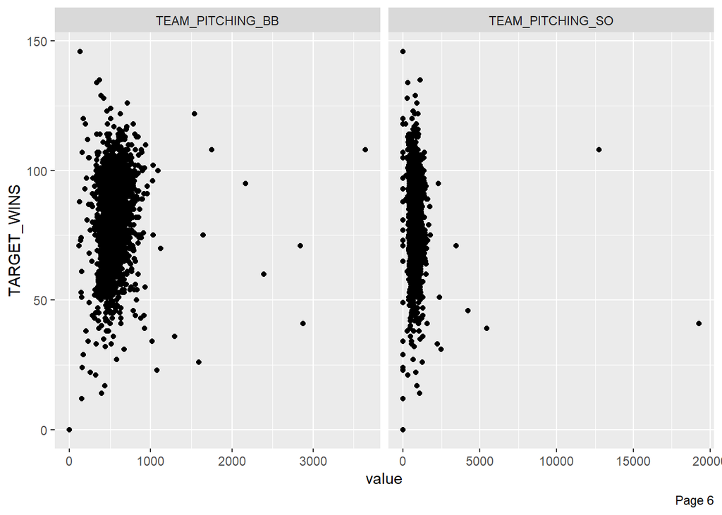

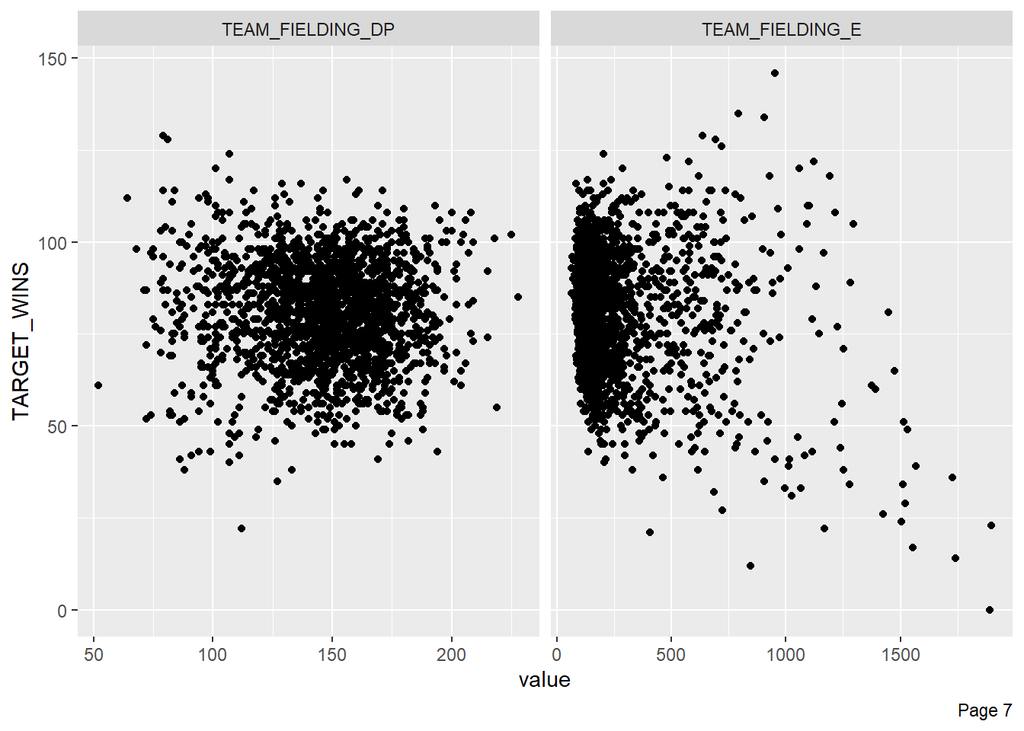

```r
plot_scatterplot(money[,-c(1,11)],by="TARGET_WINS", nrow = 1L, ncol = 2L)
```

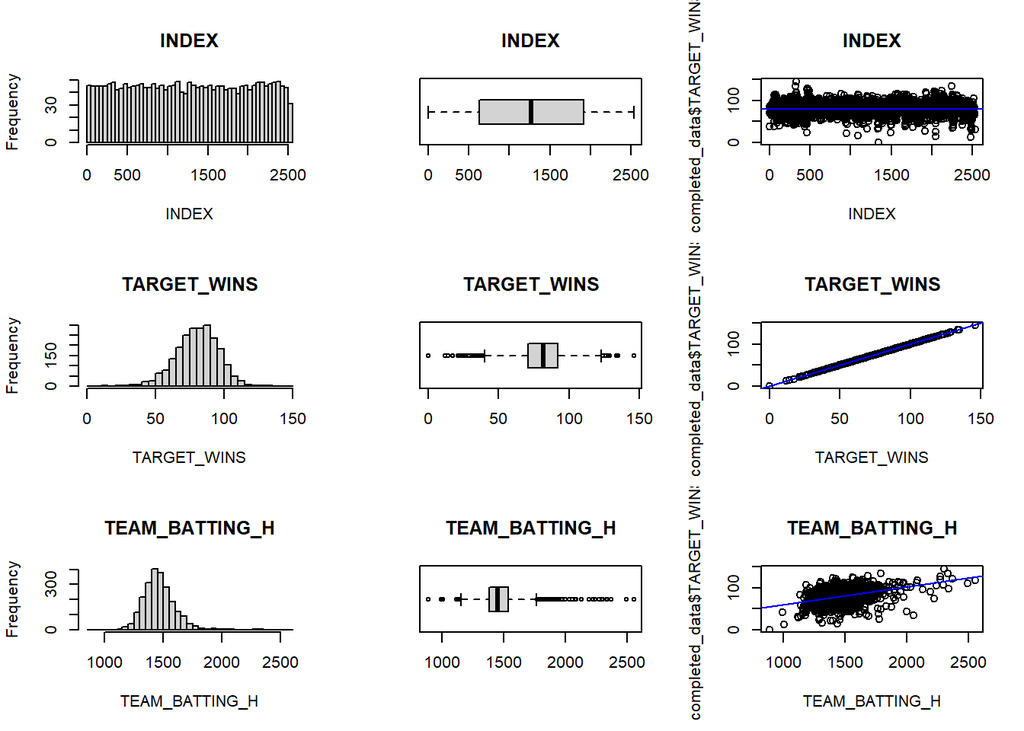

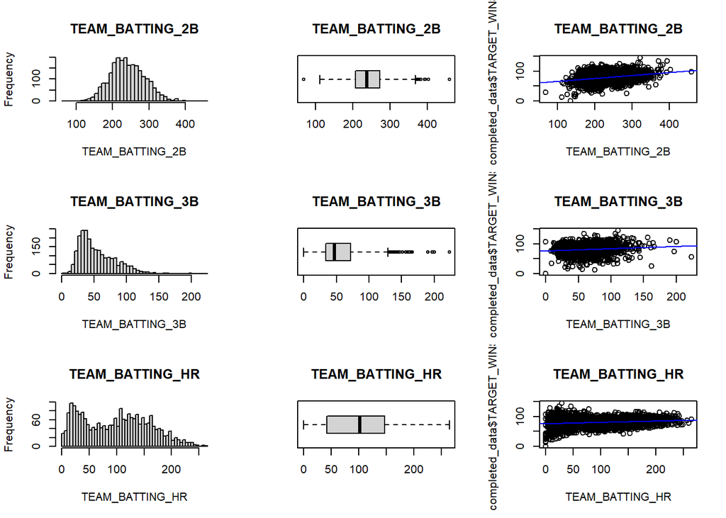

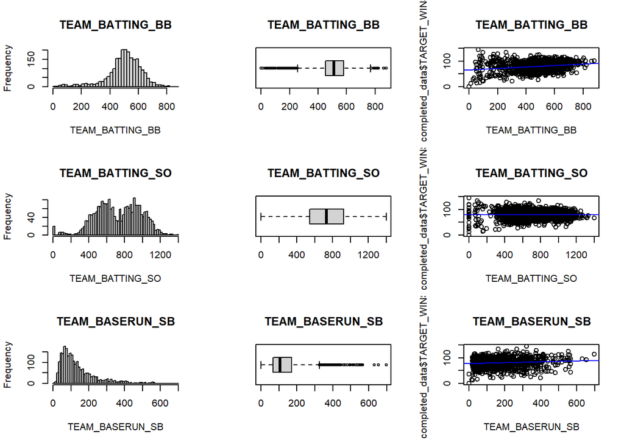

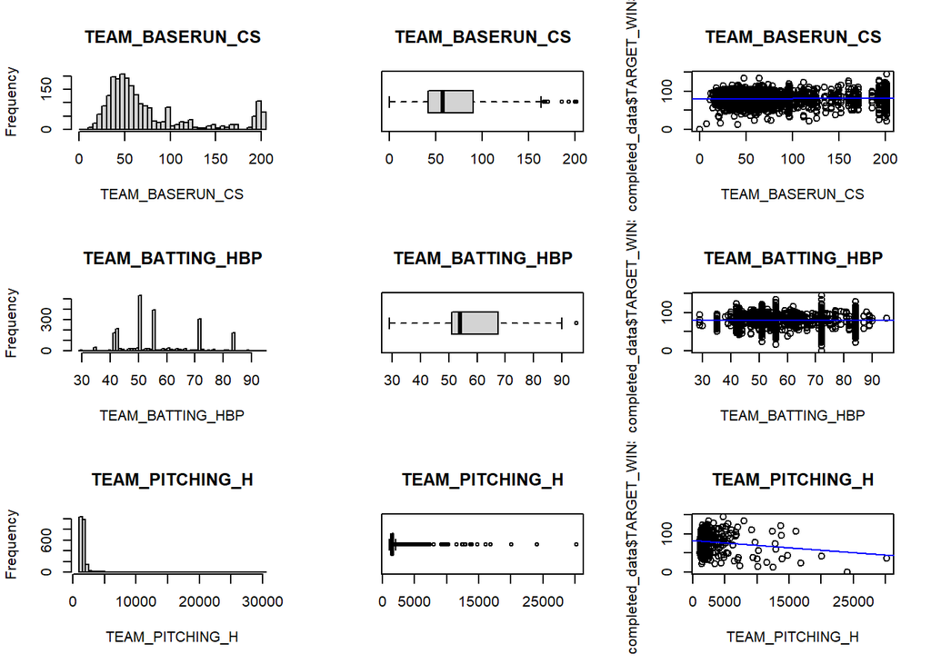

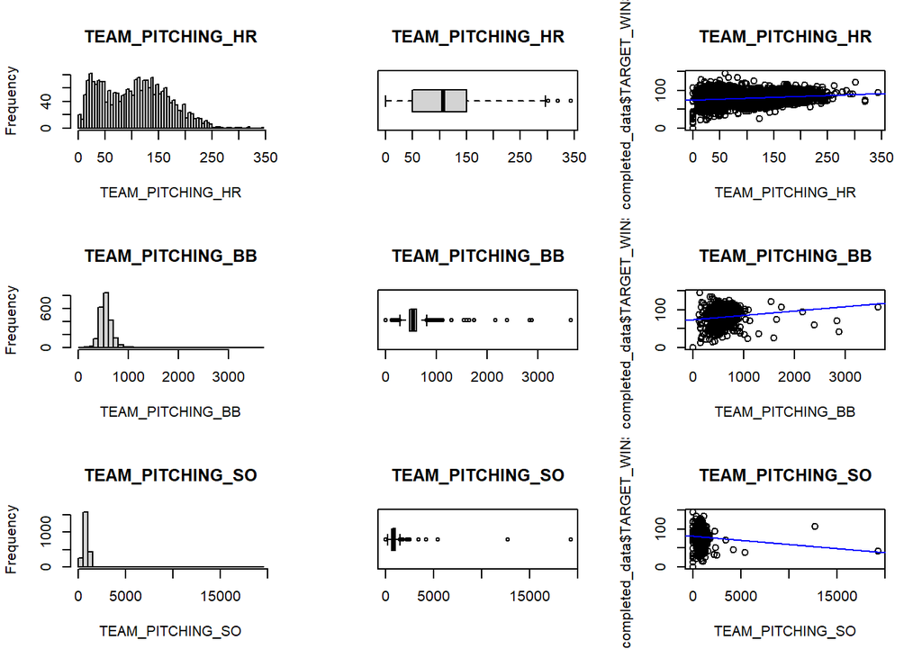

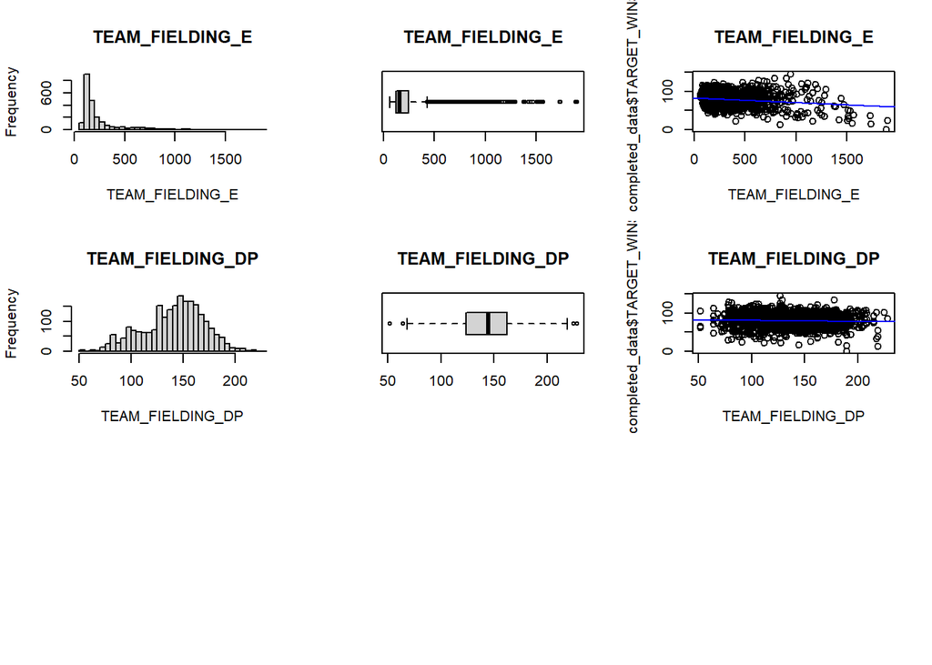

```r
# after data transformation
par(mfrow=c(3,3))
for (i in 1:17) {
  hist(completed_data[,i],main=names(completed_data[i]),xlab=names(completed_data[i]),breaks = 51)
  boxplot(completed_data[,i], main=names(completed_data[i]), type="l",horizontal = TRUE)

  plot(completed_data[,i], completed_data$TARGET_WINS, main = names(completed_data[i]), xlab=names(completed_data[i]))
  abline(lm(completed_data$TARGET_WINS ~ completed_data[,i], data = completed_data), col = "blue")
}
```

# Dealing with Outliers

The `remove_outliers_df` function removes outliers from all numeric columns in a dataset using the **Interquartile Range (IQR)** method. It loops through each column, checks if it’s numeric, and calculates the first (Q1) and third quartiles (Q3) to determine the IQR. It then sets upper and lower bounds as `Q1 - 1.5 * IQR` and `Q3 + 1.5 * IQR`, and removes any rows where the values in a numeric column fall outside these bounds. Non-numeric columns are ignored, ensuring only numeric data is affected. This results in a dataset with outliers removed from all numeric columns.

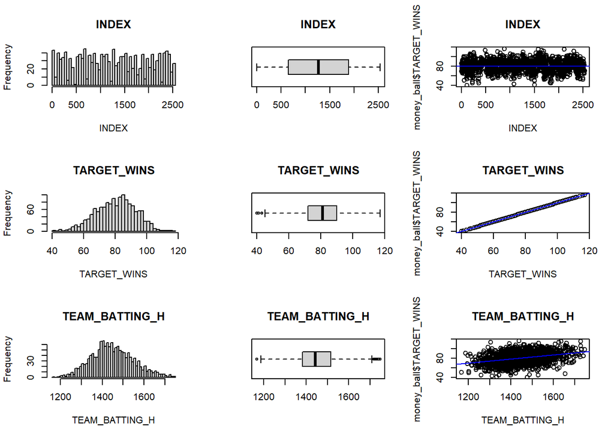

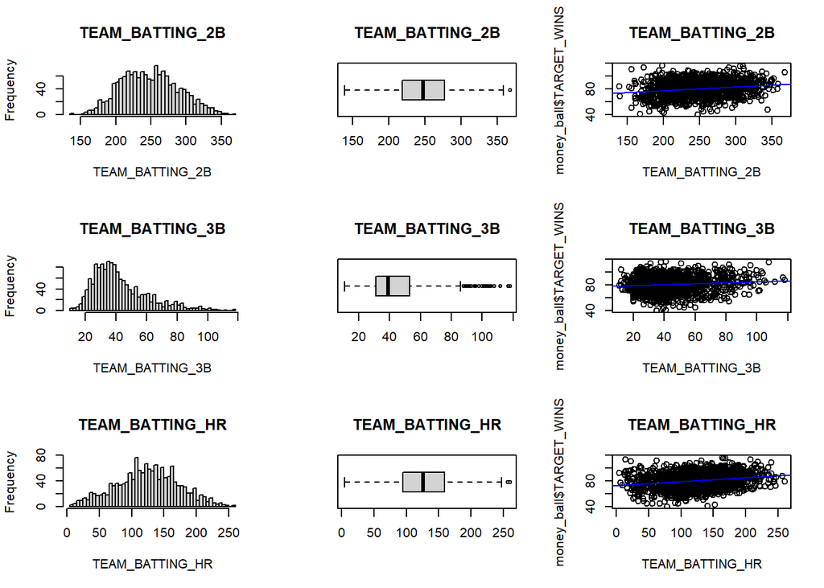

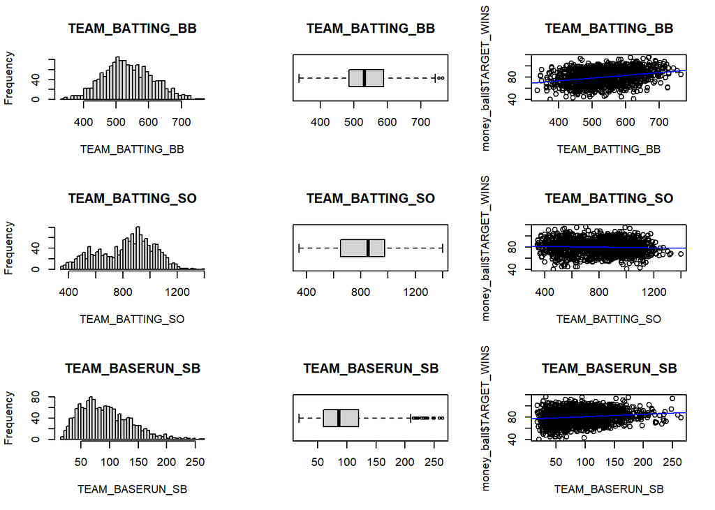

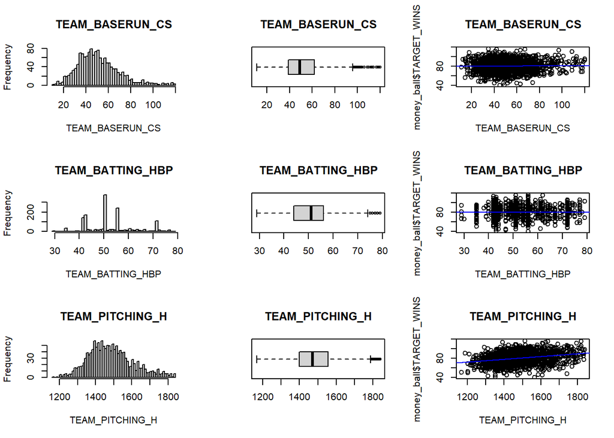

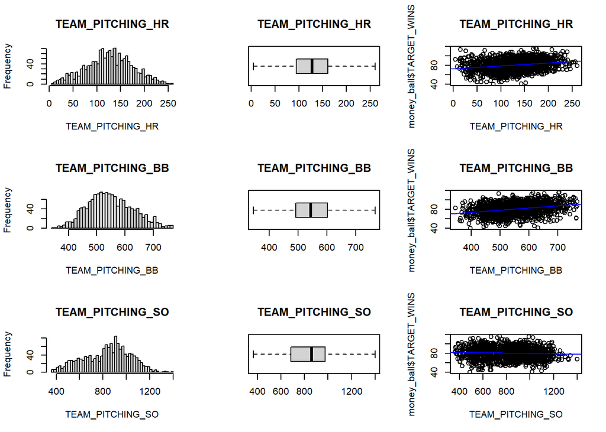

```r
remove_outliers_df <- function(df) {
  # Loop through each numeric column in the data frame
  for (col in names(df)) {
    if (is.numeric(df[[col]])) {
      # Calculate Q1, Q3, and IQR for the column
      Q1 <- quantile(df[[col]], 0.25, na.rm = TRUE)
      Q3 <- quantile(df[[col]], 0.75, na.rm = TRUE)
      IQR_value <- Q3 - Q1

      # Set lower and upper bounds
      lower_bound <- Q1 - 1.5 * IQR_value
      upper_bound <- Q3 + 1.5 * IQR_value

      # Remove rows where the value in this column is an outlier
      df <- df[df[[col]] >= lower_bound & df[[col]] <= upper_bound, ]
    }
  }
  return(df)
}

# Remove the outlier in completed dataset
money_ball <- remove_outliers_df(completed_data)
# Visualize the distribution
par(mfrow=c(3,3))
for (i in 1:17) {
  hist(money_ball[,i],main=names(money_ball[i]),xlab=names(money_ball[i]),breaks = 51)
  boxplot(money_ball[,i], main=names(money_ball[i]), type="l",horizontal = TRUE)

  plot(money_ball[,i], money_ball$TARGET_WINS, main = names(money_ball[i]), xlab=names(money_ball[i]))
  abline(lm(money_ball$TARGET_WINS ~ money_ball[,i], data = money_ball), col = "blue")

}
```

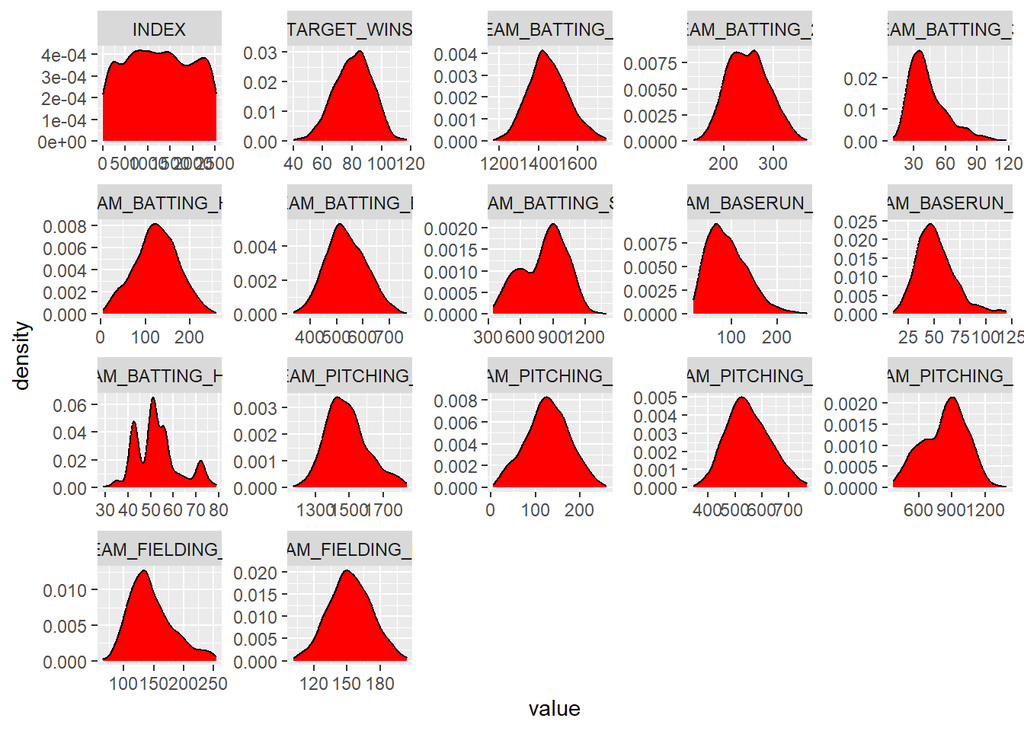

```r
# see how the density plot shows distribution
melt(money_ball) %>% ggplot(aes(x= value)) +
  geom_density(fill='red') + facet_wrap(~variable, scales = 'free')
```

The density plot shows how the values of each variable are distributed across the range. Peaks in the density curve indicate where values are concentrated, while troughs represent areas with fewer observations. After removing outliers, let see if there is an improved correlation among the variables.

```r
# Example usage
corre_updated_results <- calculate_correlations_with_pvalues(money_ball, "TARGET_WINS")

# View the results
print(corre_updated_results)
```

```
##              Predictor  Correlation       PValue
## cor              INDEX  0.008422631 0.7478709021
## cor1    TEAM_BATTING_H  0.350606673 0.0000000000
## cor2   TEAM_BATTING_2B  0.191822367 0.0000000000
## cor3   TEAM_BATTING_3B  0.111664390 0.0000191181
## cor4   TEAM_BATTING_HR  0.236697472 0.0000000000
## cor5   TEAM_BATTING_BB  0.299035092 0.0000000000
## cor6   TEAM_BATTING_SO -0.055416159 0.0342992936
## cor7   TEAM_BASERUN_SB  0.156024960 0.0000000021
## cor8   TEAM_BASERUN_CS  0.034044870 0.1937143475
## cor9  TEAM_BATTING_HBP  0.010491051 0.6888672519
## cor10  TEAM_PITCHING_H  0.284528562 0.0000000000
## cor11 TEAM_PITCHING_HR  0.240569326 0.0000000000
## cor12 TEAM_PITCHING_BB  0.283175704 0.0000000000
## cor13 TEAM_PITCHING_SO -0.060685106 0.0204422392
## cor14  TEAM_FIELDING_E -0.206165061 0.0000000000
## cor15 TEAM_FIELDING_DP -0.084323398 0.0012647021
```

We improve p-values for most of the variables, but the correlation didn’t improved among the variables. As we notice the previous correlation without transformation didn’t show sign of good relationship among the target variables.

## Model Development

### 1. **Residuals vs Fitted (Top Left)**

- **Purpose**: This plot checks the linearity assumption and homoscedasticity (constant variance of residuals).
- **Interpretation**: Ideally, residuals should be randomly scattered around 0, with no discernible pattern. In this plot, if you observe a pattern (such as a curve or a funnel shape), it could indicate non-linearity or heteroscedasticity. Your plot shows a relatively random scatter, which suggests the linearity assumption is reasonable.

### 2. **Normal Q-Q (Top Right)**

- **Purpose**: This plot tests whether the residuals are normally distributed.
- **Interpretation**: If residuals are normally distributed, the points should lie approximately on the diagonal line. Deviations from this line, especially in the tails, suggest deviations from normality. In this plot, the points mostly follow the line, with some deviation at the extremes, indicating minor non-normality.

### 3. **Scale-Location (Bottom Left)**

- **Purpose**: This plot, also known as a Spread-Location plot, checks for homoscedasticity (equal spread of residuals).
- **Interpretation**: The residuals should display a random scatter across the range of fitted values. A funnel shape (either widening or narrowing) indicates heteroscedasticity. In this plot, the spread appears fairly constant, suggesting no major issues with homoscedasticity.

### **Overall Analysis**

- The diagnostics suggest that the regression model mostly satisfies the assumptions of linearity, normality of residuals, and homoscedasticity, with some minor deviations. There don’t seem to be any overly influential points that require immediate attention.

```r
# Initiate the model
model <- lm(TARGET_WINS ~ TEAM_BATTING_H + TEAM_BATTING_2B, TEAM_BATTING_3B+
              TEAM_BATTING_HR+TEAM_BATTING_BB+TEAM_BATTING_SO+TEAM_BASERUN_SB,
            data = money_ball)
# Summarize the model

summary(model)
```

```
##
## Call:
## lm(formula = TARGET_WINS ~ TEAM_BATTING_H + TEAM_BATTING_2B,
##     data = money_ball, subset = TEAM_BATTING_3B + TEAM_BATTING_HR +
##         TEAM_BATTING_BB + TEAM_BATTING_SO + TEAM_BASERUN_SB)
##
## Residuals:
##      Min       1Q   Median       3Q      Max
## -29.7254  -6.7995   0.8316   7.9832  27.1711
##
## Coefficients:
##                   Estimate Std. Error t value Pr(>|t|)
## (Intercept)     -14.348909   8.138684  -1.763   0.0787 .
## TEAM_BATTING_H    0.071071   0.006925  10.262   <2e-16 ***
## TEAM_BATTING_2B  -0.032190   0.017874  -1.801   0.0725 .
## ---
## Signif. codes:  0 '***' 0.001 '**' 0.01 '*' 0.05 '.' 0.1 ' ' 1
##
## Residual standard error: 10.89 on 379 degrees of freedom
##   (1077 observations deleted due to missingness)
## Multiple R-squared:  0.2666, Adjusted R-squared:  0.2627
## F-statistic: 68.89 on 2 and 379 DF,  p-value: < 2.2e-16
```

```r
# Model 1 evaluation
mse <- mean(model$residuals^2)
r_squared <- summary(model)$r.squared
f_stat <- summary(model)$fstatistic[1]
print(paste("MSE:", mse, "R-squared:", r_squared, "F-statistic:", f_stat))
```

```
## [1] "MSE: 117.749712981721 R-squared: 0.266614543985386 F-statistic: 68.8907254307806"
```

```r
predictions <- predict(model, newdata = money_ball_eval)
head(predictions)
```

```
##        1        2        3        4        5        6
## 66.10329 67.56775 78.90397 85.08222 81.81371 79.75645
```

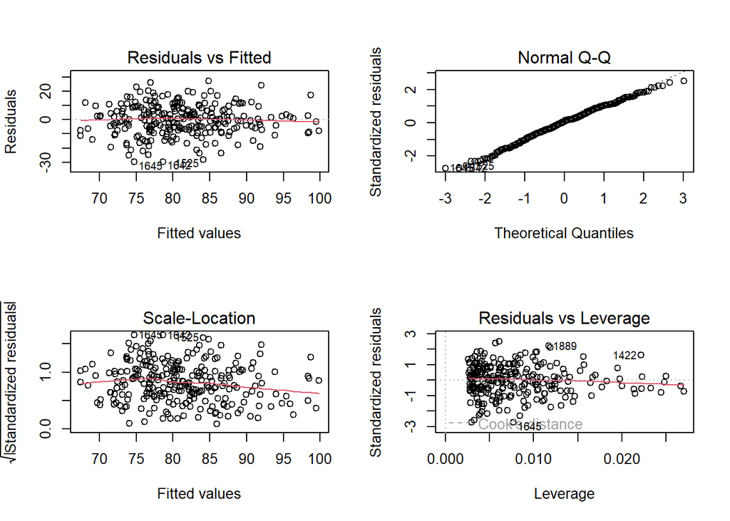

```r
par(mfrow=c(2,2))
plot(model)
```

```r
# Ensure there are no missing values in both predictors and the target
df_complete <- money_ball[complete.cases(money_ball), ]


# Separate the predictors and target (assuming 'target' is the target column)
df_predictors <- df_complete[, -which(names(df_complete) == "TARGET_WINS")]
target <- df_complete$TARGET_WINS  # Target variable

# Standardize the predictors (without the target column)
df_standardized <- scale(df_predictors)
# Perform PCA
pca_model <- prcomp(df_standardized, center = TRUE, scale. = TRUE)

# Create a data frame from the principal components
df_pca <- as.data.frame(pca_model$x)

# Ensure that PCA dataframe has the same number of rows as the original data

# Perform PCA
pca_model <- prcomp(df_standardized, center = TRUE, scale. = TRUE)

# Create a data frame from the principal components
df_pca <- as.data.frame(pca_model$x)

# Ensure that PCA dataframe has the same number of rows as the original data


# Add target variable to the PCA dataframe
df_pca$TARGET_WINS <- target



# Fit linear regression model using the first few principal components
# Fit linear regression model using the first few principal components
model1 <- lm(TARGET_WINS ~ PC1 + PC2 + PC3 + PC4+ PC5 + PC6+ PC7 + PC8, data = df_pca)

# View the summary of the model
summary(model1)
```

```
##
## Call:
## lm(formula = TARGET_WINS ~ PC1 + PC2 + PC3 + PC4 + PC5 + PC6 +
##     PC7 + PC8, data = df_pca)
##
## Residuals:
##     Min      1Q  Median      3Q     Max
## -39.985  -7.713   0.464   7.847  36.254
##
## Coefficients:
##             Estimate Std. Error t value Pr(>|t|)
## (Intercept)  80.8163     0.2893 279.393  < 2e-16 ***
## PC1           0.2117     0.1298   1.631  0.10308
## PC2           2.7194     0.1653  16.447  < 2e-16 ***
## PC3           0.6993     0.2126   3.289  0.00103 **
## PC4          -2.3335     0.2232 -10.454  < 2e-16 ***
## PC5          -0.4105     0.2922  -1.405  0.16030
## PC6          -1.0037     0.3047  -3.294  0.00101 **
## PC7           0.6186     0.3207   1.929  0.05394 .
## PC8          -2.7034     0.4049  -6.677 3.47e-11 ***
## ---
## Signif. codes:  0 '***' 0.001 '**' 0.01 '*' 0.05 '.' 0.1 ' ' 1
##
## Residual standard error: 11.05 on 1450 degrees of freedom
## Multiple R-squared:  0.2386, Adjusted R-squared:  0.2344
## F-statistic:  56.8 on 8 and 1450 DF,  p-value: < 2.2e-16
```

```r
mse1 <- mean(model1$residuals^2)
r_squared1 <- summary(model1)$r.squared
f_stat1 <- summary(model1)$fstatistic[1]
print(paste("MSE:", mse1, "R-squared:", r_squared1, "F-statistic:", f_stat1))
```

```
## [1] "MSE: 121.320828721043 R-squared: 0.238603118226332 F-statistic: 56.7993069235844"
```

```r
predictions1 <- predict(pca_model, newdata = money_ball_eval)
head(predictions1)
```

```
##            PC1      PC2       PC3       PC4        PC5         PC6        PC7
## [1,]  465.9440 1322.827  565.4319 -462.6089  27.695628  -2.0105539 -66.799173
## [2,]  357.2001 1400.106  455.2850 -484.2694  40.777104  -0.6514118 -60.430962
## [3,]  191.4738 1578.468  525.4015 -469.1025  16.372364   0.6083925   4.561732
## [4,]  276.2762 1746.431  738.1472 -514.8258   7.271371  17.1923851  50.298446
## [5,] -776.5872 2410.551 1247.2053 -195.2900 -93.431432 -70.8506852 238.264993
## [6,] -631.7089 2043.731  941.4270 -386.8419 -30.675285 -55.7001848 120.519500
##             PC8       PC9       PC10       PC11      PC12        PC13
## [1,]  -89.53094 -961.2265 -103.57059  -426.5717 -1451.700    66.96620
## [2,] -109.81589 -819.1534  -94.00623  -423.5102 -1382.211    70.91550
## [3,] -146.01940 -711.2351  -69.02262  -473.1290 -1432.742    72.25565
## [4,] -146.37085 -770.3900  -72.46692  -529.0067 -1496.699    52.81823
## [5,] -557.14326 -856.0674   83.89420 -1028.9597 -2466.804 -1484.24030
## [6,] -418.43962 -646.4252  133.46033  -865.6571 -1827.902  -817.21623
##            PC14      PC15       PC16
## [1,]  -78.10942  10.53647  -64.90391
## [2,]  -73.98762  13.45572  -60.93782
## [3,]  -76.31292  22.25110  -65.18016
## [4,]  -85.04284  26.03535  -73.21157
## [5,] -264.78897 773.09017 -394.55557
## [6,] -188.96063 372.11987 -215.08136
```

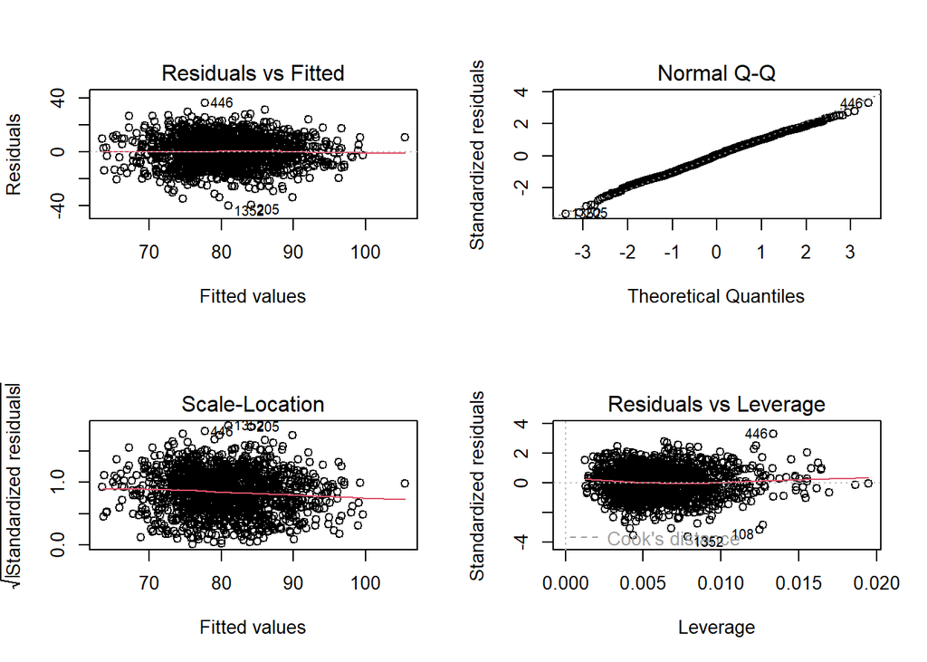

```r
par(mfrow=c(2,2))
plot(model1)
```